# Comprehensive Analysis of Accidental Drug-Related Deaths

Connecticut 2012-2024: Trends, Patterns, and Risk Factors in the Opioid Epidemic

Praisie

2026-02-04

# 1 Executive Summary

## 1.1 Overview

This comprehensive report analyzes **accidental drug-related deaths in Connecticut** spanning from 2012 to 2024. Using rigorous epidemiological methods, we identify critical trends in the opioid epidemic, characterize demographic risk patterns, and quantify the devastating impact of synthetic opioids on mortality rates.

## 1.2 Public Health Implications

**URGENT PUBLIC HEALTH ACTIONS NEEDED:**

1. **Harm Reduction**: Widespread distribution of fentanyl test strips and naloxone
2. **Treatment Expansion**: Increase access to medication-assisted treatment (MAT)
3. **Surveillance Enhancement**: Real-time monitoring of drug supply changes
4. **Targeted Prevention**: Demographic-specific intervention programs
5. **Policy Reform**: Evidence-based drug policy and decriminalization

# 2 Introduction

## 2.1 Background and Context

The opioid epidemic represents one of the most devastating public health crises in modern American history. Connecticut, like many states, has experienced catastrophic losses due to drug overdoses, with evolving patterns reflecting rapid changes in the illicit drug supply and shifting prescription practices.

### 2.1.1 Evolution of the Crisis

The epidemic has progressed through three distinct waves:

1. **Wave 1 (1990s-2000s)**: Rise in prescription opioid-related overdose deaths
2. **Wave 2 (2010-2013)**: Rapid increase in heroin-related deaths
3. **Wave 3 (2013-present)**: Surge in synthetic opioid deaths, particularly fentanyl

## 2.2 Study Objectives

This analysis aims to:

1. **Characterize** the demographic and temporal patterns of drug-related deaths
2. **Quantify** the prevalence of specific substances, particularly opioids and fentanyl
3. **Identify** risk factors associated with overdose mortality
4. **Analyze** poly-drug use patterns and their temporal evolution
5. **Model** predictors of opioid involvement using multivariable regression

## 2.3 Data Source

- **Source**: Data.gov
- **Period**: 2012-2024
- **Data Type**: Death investigation records with comprehensive toxicology
- **Geographic Coverage**: All Connecticut counties

# 3 Methods

## 3.1 Software and Analytical Approach

```r
# Install required packages (run once)
install.packages(c("tidyverse", "survival", "rmarkdown", "tableone",
                   "gtsummary", "glue", "rlang", "xfun"))
```

```r
# Load required libraries
library(tidyverse)      # Data manipulation and visualization
library(lubridate)      # Date handling
library(tableone)       # Descriptive statistics tables
library(gtsummary)      # Publication-quality tables
library(ggplot2)        # Advanced visualization
library(broom)          # Model output tidying

# Create output directory
if (!dir.exists("outputs")) {
  dir.create("outputs")
}
```

**Analysis Framework:**  
We employ a comprehensive epidemiological approach combining descriptive statistics, temporal trend analysis, and multivariable regression modeling to understand patterns and predictors of drug-related mortality.

## 3.2 Data Import

```r
# Read the dataset
deaths <- read_csv("C://Users//pc//Downloads//Accidental_Drug_Related_Deaths_2012-2024.csv")

# Display dataset dimensions
cat("Original dataset:", nrow(deaths), "observations ×", ncol(deaths), "variables\n")
```

```
Original dataset: 12963 observations × 48 variables
```

**Data Structure:**  
The dataset contains comprehensive death investigation records including demographic information, toxicology results indicating presence/absence of specific substances, location data, and circumstances of death. Each row represents one fatal overdose case.

# 4 Data Exploration and Quality Assessment

## 4.1 Initial Data Examination

```r
# View first few rows
head(deaths)
```

| Date | Date Type | Age | Sex | Race | Ethnicity | Residence City | Residence County | Residence State | Injury City | Injury County | Injury State | Injury Place | Description of Injury | Death City | Death County | Death State | Location | Location if Other | Cause of Death | Manner of Death | Other Significant Conditions | Heroin | Heroin death certificate (DC) | Cocaine | Fentanyl | Fentanyl Analogue | Oxycodone | Oxymorphone | Ethanol | … |
| --- | --- | --- | --- | --- | --- | --- | --- | --- | --- | --- | --- | --- | --- | --- | --- | --- | --- | --- | --- | --- | --- | --- | --- | --- | --- | --- | --- | --- | --- | --- |
| 1/2/2023 | Date of death | 65 | Male | White | No, not Spanish/Hispanic/Latino | BRIDGEPORT | FAIRFIELD | CT | BRIDGEPORT | FAIRFIELD | NA | Other | Substance use | NA | NA | NA | NA | NA | Acute Intoxication by the Combined Effects of Fentanyl and Cocaine | Accident | NA | NA | NA | Y | Y | NA | NA | NA | NA | … |
| 1/18/2023 | Date of death | 42 | Male | White | No, not Spanish/Hispanic/Latino | WATERBURY | NEW HAVEN | CT | FARMINGTON | HARTFORD | CT | Home | Ethanol and Fentanyl Use | NA | NA | NA | NA | NA | Combined Effects of Fentanyl and Ethanol Toxicity | Accident | NA | NA | NA | NA | Y | NA | NA | NA | Y | … |
| 1/26/2022 | Date of death | 34 | Male | White | NA | BROOKFIELD | FAIRFIELD | CT | BROOKFIELD | FAIRFIELD | CT | Home | Substance Abuse | NA | NA | NA | Decedent’s Home | NA | Acute Intoxication due to the Combined Effects of Fentanyl, Heroin, Xylazine and Clonazepam | Accident | NA | Y | NA | NA | Y | NA | NA | NA | NA | … |
| 2/4/2023 | Date of death | 34 | Male | White | NA | NA | NA | NA | NEW HAVEN | NEW HAVEN | CT | Other | Substance Use | NA | NA | NA | NA | NA | Acute Fentanyl Intoxication with Recent Cocaine Use | Accident | NA | NA | NA | Y | Y | NA | NA | NA | NA | … |
| 2/18/2022 | Date of death | 43 | Male | White | NA | NORWICH | NEW LONDON | CT | NORWICH | NEW LONDON | CT | Public Recreation Area | Drug Use | NA | NA | NA | Other (Specify) | Mohegan Park | Acute Cocaine and Fentanyl Intoxication | Accident | NA | NA | NA | Y | Y | NA | NA | NA | NA | … |
| 2/18/2022 | Date of death | 38 | Male | White | NA | WATERBURY | NEW HAVEN | CT | WATERBURY | NEW HAVEN | CT | Home | Drug use | NA | NA | NA | Hospital - ER/Outpatient | NA | Acute Intoxication Combined Effects of Ethanol, Cocaine, and Heroin | Accident | NA | Y | NA | Y | NA | NA | NA | NA | Y | … |

```r
# Examine structure
glimpse(deaths)
```

```
Rows: 12,963
Columns: 48
$ Date                            <chr> "1/2/2023", "1/18/2023", "1/26/2022", …
$ `Date Type`                     <chr> "Date of death", "Date of death", "Dat…
$ Age                             <dbl> 65, 42, 34, 34, 43, 38, 27, 24, 77, 24…
$ Sex                             <chr> "Male", "Male", "Male", "Male", "Male"…
$ Race                            <chr> "White", "White", "White", "White", "W…
$ Ethnicity                       <chr> "No, not Spanish/Hispanic/Latino", "No…
$ `Residence City`                <chr> "BRIDGEPORT", "WATERBURY", "BROOKFIELD…
$ `Residence County`              <chr> "FAIRFIELD", "NEW HAVEN", "FAIRFIELD",…
$ `Residence State`               <chr> "CT", "CT", "CT", NA, "CT", "CT", "CT"…
$ `Injury City`                   <chr> "BRIDGEPORT", "FARMINGTON", "BROOKFIEL…
$ `Injury County`                 <chr> "FAIRFIELD", "HARTFORD", "FAIRFIELD", …
$ `Injury State`                  <chr> NA, "CT", "CT", "CT", "CT", "CT", "CT"…
$ `Injury Place`                  <chr> "Other", "Home", "Home", "Other", "Pub…
```

[output cut: 35 more lines]

**Variable Types:**  
The dataset includes: - **Categorical variables**: Sex, Race, drug indicators (Y/N format) - **Continuous variables**: Age, Date - **Geographic variables**: City, location details - **Toxicology indicators**: Multiple substance detection columns

Drug variables are coded as Y (detected), N (not detected), or missing (not tested).

## 4.2 Missing Data Analysis

```r
# Comprehensive missing data assessment
missing_summary <- colSums(is.na(deaths))
missing_df <- data.frame(
  Variable = names(missing_summary),
  Missing_Count = missing_summary,
  Missing_Percent = round(missing_summary / nrow(deaths) * 100, 2)
) %>%
  arrange(desc(Missing_Count)) %>%
  filter(Missing_Count > 0)

print(missing_df)
```

```
                                                   Variable Missing_Count
Morphine (Not Heroin)                 Morphine (Not Heroin)         12901
Hydromorphone                                 Hydromorphone         12883
Meth/Amphetamine                           Meth/Amphetamine         12836
Opiate NOS                                       Opiate NOS         12835
Hydrocodone                                     Hydrocodone         12790
Oxymorphone                                     Oxymorphone         12788
Tramad                                               Tramad         12653
Other Opioid                                   Other Opioid         12650
Amphet                                               Amphet         12468
Gabapentin                                       Gabapentin         12408
Heroin death certificate (DC) Heroin death certificate (DC)         12223
Other                                                 Other         12086
Fentanyl Analogue                         Fentanyl Analogue         11942
Oxycodone                                         Oxycodone         11893
Methadone                                         Methadone         11772
Location if Other                         Location if Other         11769
Other Significant Conditions   Other Significant Conditions         11614
Xylazine                                           Xylazine         11543
Heroin/Morph/Codeine                   Heroin/Morph/Codeine         10700
Benzodiazepine                               Benzodiazepine         10052
Ethanol                                             Ethanol          9630
Ethnicity                                         Ethnicity          9528
Heroin                                               Heroin          9324
Cocaine                                             Cocaine          7799
Death State                                     Death State          6090
Death County                                   Death County          4873
Fentanyl                                           Fentanyl          4152
Death City                                       Death City          3766
Injury County                                 Injury County          3436
Any Opioid                                       Any Opioid          3171
Injury State                                   Injury State          3114
Location                                           Location          2331
Residence State                             Residence State          2036
Residence County                           Residence County          1308
Description of Injury                 Description of Injury           813
Residence City                               Residence City           643
Injury Place                                   Injury Place           390
InjuryCityGeo                                 InjuryCityGeo           280
Injury City                                     Injury City           257
```

[output cut: 37 more lines]

```
Injury State                            24.02
Location                                17.98
Residence State                         15.71
Residence County                        10.09
Description of Injury                    6.27
Residence City                           4.96
Injury Place                             3.01
InjuryCityGeo                            2.16
Injury City                              1.98
ResidenceCityGeo                         1.30
Race                                     0.51
Sex                                      0.07
Manner of Death                          0.07
Age                                      0.02
DeathCityGeo                             0.01
```

**Missing Data Patterns:**  
Missing data reflects real-world data collection challenges: - Some substances may not have been tested in all cases - Demographic information occasionally incomplete - Missing toxicology data does NOT mean substance was absent, only that it wasn’t detected/tested - Critical variables (Date, Age) have minimal missingness

## 4.3 Categorical Variables Exploration

```r
# Examine key categorical variables
cat("=== SEX DISTRIBUTION ===\n")
```

```
=== SEX DISTRIBUTION ===
```

```r
table(deaths$Sex, useNA = "always")
```

```
 Female    Male Unknown       X    <NA>
   3380    9571       2       1       9
```

```r
cat("\n=== RACE DISTRIBUTION ===\n")
```

```
=== RACE DISTRIBUTION ===
```

```r
table(deaths$Race, useNA = "always")
```

```
                        American Indian or Alaska Native
                                                       6
                                                   Asian
                                                       4
                                            Asian Indian
                                                      31
                                            Asian, Other
                                                      24
                                            Asian/Indian
                                                       5
                                                   Black
                                                     809
                               Black or African American
                                                    1027
Black or African American / American Indian Lenni Lenape
                                                       1
                                                 Chinese
                                                       2
                                                Hawaiian
                                                       1
                                                Japanese
                                                       1
                                                  Korean
                                                       1
                                  Native American, Other
                                                       1
                                                   Other
                                                      52
                                         Other (Specify)
                                                      46
                                 Other (Specify) Haitian
                                                       1
                 Other (Specify) portugese, Cape Verdean
                                                       1
                            Other (Specify) Puerto Rican
                                                       3
                                             Other Asian
                                                      12
                                   Other Asian (Specify)
                                                       1
                                                 Unknown
                                                      63
                                                   white
                                                       3
                                                   White
                                                   10802
                                                    <NA>
                                                      66
```

```r
cat("\n=== HEROIN DETECTION ===\n")
```

```
=== HEROIN DETECTION ===
```

```r
table(deaths$Heroin, useNA = "always")
```

```
   N    Y <NA>
   3 3636 9324
```

```r
cat("\n=== ANY OPIOID DETECTION ===\n")
```

```
=== ANY OPIOID DETECTION ===
```

```r
table(deaths$`Any Opioid`, useNA = "always")
```

```
   N    Y <NA>
 119 9673 3171
```

**Initial Observations:**  
- **Sex**: Predominantly male victims, consistent with national overdose patterns - **Race**: Substantial heterogeneity requiring standardization - **Drug Variables**: Y/N coding requires conversion to binary (0/1) format for statistical analysis - **Opioid Prevalence**: High proportion of cases involve opioids

# 5 Data Cleaning and Preprocessing

## 5.1 Date Variable Processing

```r
# Convert and extract date components
deaths$Date <- mdy(deaths$Date)

deaths_clean <- deaths %>%
  mutate(
    year = year(Date),
    month = month(Date),
    month_name = month(Date, label = TRUE),
    day = day(Date),
    weekday = wday(Date, label = TRUE),
    quarter = quarter(Date)
  )

# Verify date conversion
date_range <- range(deaths_clean$Date, na.rm = TRUE)
study_years <- max(deaths_clean$year, na.rm = TRUE) - min(deaths_clean$year, na.rm = TRUE) + 1

cat("Study Period:", as.character(date_range[1]), "to", as.character(date_range[2]), "\n")
```

```
Study Period: 2012-01-01 to 2024-12-31
```

```r
cat("Duration:", study_years, "years\n")
```

```
Duration: 13 years
```

**Temporal Scope:**  
The dataset spans 13 years from 2012-01-01 to 2024-12-31. The temporal variables (year, month, weekday, quarter) enable: - **Trend Analysis**: Year-over-year changes in mortality - **Seasonal Patterns**: Monthly and quarterly variation - **Day-of-Week Effects**: Potential weekend vs. weekday differences

## 5.2 Age Variable Processing

```r
# Age summary statistics
cat("=== AGE DISTRIBUTION SUMMARY ===\n")
```

```
=== AGE DISTRIBUTION SUMMARY ===
```

```r
summary(deaths_clean$Age)
```

```
   Min. 1st Qu.  Median    Mean 3rd Qu.    Max.    NA's
  13.00   34.00   44.00   44.35   55.00   87.00       2
```

```r
# Create meaningful age groups
deaths_clean <- deaths_clean %>%
  mutate(
    # Detailed age groups for granular analysis
    age_group = cut(Age,
                    breaks = c(0, 18, 25, 35, 45, 55, 65, 100),
                    labels = c("0-17", "18-24", "25-34", "35-44",
                               "45-54", "55-64", "65+"),
                    right = FALSE),

    # Broader grouping for high-level comparisons
    age_group_broad = cut(Age,
                          breaks = c(0, 30, 50, 65, 100),
                          labels = c("<30", "30-49", "50-64", "65+"),
                          right = FALSE)
  )

# Identify potential outliers
outliers <- deaths_clean %>%
  filter(Age < 10 | Age > 90) %>%
  select(Age, Sex, Date) %>%
  arrange(Age)

cat("\nPotential age outliers identified:", nrow(outliers), "cases\n")
```

```
Potential age outliers identified: 0 cases
```

```r
if(nrow(outliers) > 0 && nrow(outliers) <= 20) {
  print(outliers)
}
```

**Age Characteristics:**  
Mean age is approximately 44.4 years with a median of 44 years. The distribution: - Reflects middle-age concentration of overdose deaths - Age groups enable comparison across life stages - Outliers (very young or elderly) may represent data entry errors or unusual cases - Peak risk appears in the 35-54 age range

## 5.3 Sex Variable Standardization

```r
# Review original sex categories
cat("=== ORIGINAL SEX DISTRIBUTION ===\n")
```

```
=== ORIGINAL SEX DISTRIBUTION ===
```

```r
table(deaths_clean$Sex, useNA = "always")
```

```
 Female    Male Unknown       X    <NA>
   3380    9571       2       1       9
```

```r
# Standardize sex variable
deaths_clean <- deaths_clean %>%
  mutate(
    Sex_clean = case_when(
      Sex == "Male" ~ "Male",
      Sex == "Female" ~ "Female",
      Sex %in% c("Unknown", "X") ~ NA_character_,
      is.na(Sex) ~ NA_character_,
      TRUE ~ NA_character_
    ),
    Sex_clean = factor(Sex_clean, levels = c("Male", "Female"))
  )

# Verify cleaning
cat("\n=== CLEANED SEX DISTRIBUTION ===\n")
```

```
=== CLEANED SEX DISTRIBUTION ===
```

```r
sex_table <- table(deaths_clean$Sex_clean, useNA = "always")
print(sex_table)
```

```
  Male Female   <NA>
  9571   3380     12
```

```r
# Calculate proportions
sex_props <- prop.table(sex_table[!is.na(names(sex_table))]) * 100
```

**Sex Distribution:**  
After standardization, the sample consists of 73.9% males and 26.1% females (excluding missing data). This approximately 3:1 male-to-female ratio is consistent with: - National overdose mortality patterns - Higher risk-taking behaviors among males - Greater prevalence of substance use disorders in men - Potential gender differences in drug use patterns and treatment-seeking

## 5.4 Race/Ethnicity Variable Cleaning

```r
# View original race categories
cat("=== ORIGINAL RACE CATEGORIES ===\n")
```

```
=== ORIGINAL RACE CATEGORIES ===
```

```r
print(table(deaths_clean$Race, useNA = "always"))
```

```
                        American Indian or Alaska Native
                                                       6
                                                   Asian
                                                       4
                                            Asian Indian
                                                      31
                                            Asian, Other
                                                      24
                                            Asian/Indian
                                                       5
                                                   Black
                                                     809
                               Black or African American
                                                    1027
Black or African American / American Indian Lenni Lenape
                                                       1
                                                 Chinese
                                                       2
                                                Hawaiian
                                                       1
                                                Japanese
                                                       1
                                                  Korean
                                                       1
                                  Native American, Other
                                                       1
                                                   Other
                                                      52
                                         Other (Specify)
                                                      46
                                 Other (Specify) Haitian
                                                       1
                 Other (Specify) portugese, Cape Verdean
                                                       1
                            Other (Specify) Puerto Rican
                                                       3
                                             Other Asian
                                                      12
                                   Other Asian (Specify)
                                                       1
                                                 Unknown
                                                      63
                                                   white
                                                       3
                                                   White
                                                   10802
                                                    <NA>
                                                      66
```

```r
# Standardize and group race categories
deaths_clean <- deaths_clean %>%
  mutate(
    race_temp = str_to_title(Race),
    Race_clean = case_when(
      str_detect(race_temp, "^White") ~ "White",
      str_detect(race_temp, "Black|African American") ~ "Black",
      str_detect(race_temp, "Hispanic|Latino") ~ "Hispanic/Latino",
      str_detect(race_temp, "Asian|Chinese|Korean|Japanese|Indian") ~ "Asian",
      str_detect(race_temp, "Native|Indian|Alaska|Lenape|Hawaiian") ~ "Native American",
      str_detect(race_temp, "Other|Haitian|Cape Verdean|Puerto Rican") ~ "Other",
      race_temp == "Unknown" | is.na(Race) ~ NA_character_,
      TRUE ~ "Other"
    ),
    Race_clean = factor(Race_clean,
                        levels = c("White", "Black", "Hispanic/Latino",
                                   "Asian", "Native American", "Other"))
  ) %>%
  select(-race_temp)

# Verify cleaning
cat("\n=== CLEANED RACE DISTRIBUTION ===\n")
```

```
=== CLEANED RACE DISTRIBUTION ===
```

```r
race_table <- table(deaths_clean$Race_clean, useNA = "always")
print(race_table)
```

```
          White           Black Hispanic/Latino           Asian Native American
          10805            1837               0              87               2
          Other            <NA>
            103             129
```

```r
# Cross-tabulation
cat("\n=== CROSS-CHECK: Original vs Cleaned ===\n")
```

```
=== CROSS-CHECK: Original vs Cleaned ===
```

```r
race_crosscheck <- deaths_clean %>%
  count(Race, Race_clean) %>%
  arrange(Race_clean)
print(race_crosscheck, n = 30)
```

```
# A tibble: 24 × 3
   Race                                                     Race_clean         n
   <chr>                                                    <fct>          <int>
 1 White                                                    White          10802
 2 white                                                    White              3
 3 Black                                                    Black            809
 4 Black or African American                                Black           1027
 5 Black or African American / American Indian Lenni Lenape Black              1
 6 American Indian or Alaska Native                         Asian              6
 7 Asian                                                    Asian              4
 8 Asian Indian                                             Asian             31
 9 Asian, Other                                             Asian             24
10 Asian/Indian                                             Asian              5
11 Chinese                                                  Asian              2
12 Japanese                                                 Asian              1
13 Korean                                                   Asian              1
14 Other Asian                                              Asian             12
15 Other Asian (Specify)                                    Asian              1
16 Hawaiian                                                 Native Americ…     1
17 Native American, Other                                   Native Americ…     1
18 Other                                                    Other             52
19 Other (Specify)                                          Other             46
20 Other (Specify) Haitian                                  Other              1
21 Other (Specify) Puerto Rican                             Other              3
22 Other (Specify) portugese, Cape Verdean                  Other              1
23 Unknown                                                  <NA>              63
24 <NA>                                                     <NA>              66
```

**Race/Ethnicity Standardization:**  
The original data contained 24 unique race categories, requiring substantial harmonization. After cleaning: - Consolidated into 6 major categories plus missing - Resolved inconsistent spelling and capitalization - Grouped related ethnic subgroups - Preserved meaningful demographic distinctions for health equity analysis

This standardization enables valid statistical comparisons while respecting demographic diversity.

## 5.5 Drug Variables Cleaning

```r
# Define drug columns to examine
drug_cols <- c("Heroin", "Cocaine", "Fentanyl", "Oxycodone",
               "Benzodiazepine", "Meth/Amphetamine", "Any Opioid")

# Examine each drug variable
cat("=== DRUG VARIABLE DISTRIBUTIONS ===\n")
```

```
=== DRUG VARIABLE DISTRIBUTIONS ===
```

```r
for(col in drug_cols) {
  if(col %in% names(deaths_clean)) {
    cat("\n", col, ":\n")
    print(table(deaths_clean[[col]], useNA = "always"))
  }
}
```

```
 Heroin :

   N    Y <NA>
   3 3636 9324

 Cocaine :

   Y <NA>
5164 7799

 Fentanyl :

       Y Y (PTCH)   Y POPS     <NA>
    8809        1        1     4152

 Oxycodone :

    Y  <NA>
 1070 11893

 Benzodiazepine :

    Y  <NA>
 2911 10052

 Meth/Amphetamine :

    Y  <NA>
  127 12836

 Any Opioid :

   N    Y <NA>
 119 9673 3171
```

```r
# Convert all drug variables to binary (1/0)
deaths_clean <- deaths_clean %>%
  mutate(
    across(
      c(Heroin, Cocaine, Fentanyl, `Fentanyl Analogue`,
        Oxycodone, Oxymorphone, Ethanol, Hydrocodone,
        Benzodiazepine, Methadone, `Meth/Amphetamine`,
        Tramad, Hydromorphone, `Morphine (Not Heroin)`,
        Xylazine, Gabapentin, `Any Opioid`),
      ~case_when(
        . == "Y" ~ 1,
        . == "N" ~ 0,
        is.na(.) ~ 0,
        TRUE ~ 0
      ),
      .names = "{.col}_binary"
    )
  )

# Verify conversion
cat("\n=== SAMPLE OF BINARY CONVERSION ===\n")
```

```
=== SAMPLE OF BINARY CONVERSION ===
```

```r
deaths_clean %>%
  select(Heroin, Heroin_binary, Fentanyl, Fentanyl_binary) %>%
  head(20) %>%
  print()
```

```
# A tibble: 20 × 4
   Heroin Heroin_binary Fentanyl Fentanyl_binary
   <chr>          <dbl> <chr>              <dbl>
 1 <NA>               0 Y                      1
 2 <NA>               0 Y                      1
 3 Y                  1 Y                      1
 4 <NA>               0 Y                      1
 5 <NA>               0 Y                      1
 6 Y                  1 <NA>                   0
 7 <NA>               0 Y                      1
 8 <NA>               0 Y                      1
 9 <NA>               0 Y                      1
10 <NA>               0 Y                      1
11 <NA>               0 Y                      1
12 <NA>               0 Y                      1
13 <NA>               0 Y                      1
14 <NA>               0 <NA>                   0
15 <NA>               0 Y                      1
16 <NA>               0 Y                      1
17 Y                  1 Y                      1
18 <NA>               0 Y                      1
19 <NA>               0 Y                      1
20 <NA>               0 Y                      1
```

**Drug Variable Transformation:**  
Converting Y/N format to binary (1/0) enables: - **Quantitative Analysis**: Sum to count total drugs involved - **Statistical Modeling**: Use as predictors in regression models - **Standardization**: Consistent format across all substance variables

**Important Note**: Missing values coded as 0 (not detected). This is a conservative approach but may underestimate substance involvement if testing was incomplete.

## 5.6 Derived Variables Creation

```r
# Create analytical variables
deaths_clean <- deaths_clean %>%
  mutate(
    # Count total drugs detected per case
    num_drugs = Heroin_binary + Cocaine_binary + Fentanyl_binary +
      Oxycodone_binary + Benzodiazepine_binary +
      `Meth/Amphetamine_binary` + Ethanol_binary,

    # Poly-drug use indicator
    poly_drug = ifelse(num_drugs > 1, "Yes", "No"),

    # Drug category indicators
    any_opioid = `Any Opioid_binary`,
    any_stimulant = ifelse(Cocaine_binary == 1 | `Meth/Amphetamine_binary` == 1, 1, 0),

    # Opioid subtypes
    prescription_opioid = ifelse(Oxycodone_binary == 1 | Hydrocodone_binary == 1 |
                                   Methadone_binary == 1, 1, 0),
    illicit_opioid = ifelse(Heroin_binary == 1 | Fentanyl_binary == 1, 1, 0),

    # Era classification (fentanyl emergence)
    fentanyl_era = ifelse(year >= 2015, "Post-2015", "Pre-2015")
  )

# Summarize derived variables
cat("=== NUMBER OF DRUGS INVOLVED ===\n")
```

```
=== NUMBER OF DRUGS INVOLVED ===
```

```r
print(table(deaths_clean$num_drugs))
```

```
   0    1    2    3    4    5    6
 426 3945 5354 2628  543   62    5
```

```r
cat("\n=== POLY-DRUG USE ===\n")
```

```
=== POLY-DRUG USE ===
```

```r
poly_table <- table(deaths_clean$poly_drug)
print(poly_table)
```

```
  No  Yes
4371 8592
```

```r
poly_pct <- round(prop.table(poly_table) * 100, 1)
cat("Poly-drug use prevalence:", poly_pct["Yes"], "%\n")
```

```
Poly-drug use prevalence: 66.3 %
```

**Derived Variable Insights:**  
- **Multiple Substance Involvement**: 66.3% of deaths involved more than one drug - **Drug Counting**: Enables quantification of poly-drug complexity - **Opioid Categories**: Distinguishes prescription vs. illicit opioids for targeted interventions - **Temporal Classification**: Pre/post-2015 captures fentanyl emergence period - **Stimulant Identification**: Tracks cocaine and methamphetamine involvement

These derived variables enable sophisticated epidemiological analysis of substance use patterns.

## 5.7 Final Data Filtering

```r
# Remove records with critical missing data
deaths_final <- deaths_clean %>%
  filter(
    !is.na(Date),           # Must have death date
    !is.na(Age),            # Must have age
    Age >= 10 & Age <= 100  # Biologically plausible age range
  )

# Calculate retention statistics
original_n <- nrow(deaths)
final_n <- nrow(deaths_final)
removed_n <- original_n - final_n
retention_pct <- round(final_n / original_n * 100, 2)

cat("=== DATA RETENTION SUMMARY ===\n")
```

```
=== DATA RETENTION SUMMARY ===
```

```r
cat("Original records:", original_n, "\n")
```

```
Original records: 12963
```

```r
cat("Final analytic sample:", final_n, "\n")
```

```
Final analytic sample: 12961
```

```r
cat("Records excluded:", removed_n, "(", round(removed_n/original_n*100, 2), "%)\n")
```

```
Records excluded: 2 ( 0.02 %)
```

```r
cat("Retention rate:", retention_pct, "%\n")
```

```
Retention rate: 99.98 %
```

**Data Quality Summary:**  
After excluding cases with missing critical variables or implausible ages, we retained 99.98% of the original dataset (12,961 cases). This high retention rate indicates: - Excellent data quality in the source system - Minimal impact of data cleaning on sample representativeness - Robust analytical dataset for epidemiological analysis

The excluded cases (2) primarily had missing dates or ages, which are essential for temporal and demographic analysis.

## 5.8 Save Cleaned Dataset

```r
# Save in multiple formats
write_csv(deaths_final, "deaths_cleaned.csv")
saveRDS(deaths_final, "deaths_cleaned.rds")

cat("✓ Cleaned data saved successfully\n")
```

```
✓ Cleaned data saved successfully
```

```r
cat("  - CSV format: deaths_cleaned.csv\n")
```

```
  - CSV format: deaths_cleaned.csv
```

```r
cat("  - RDS format: deaths_cleaned.rds (preserves R data types)\n")
```

```
  - RDS format: deaths_cleaned.rds (preserves R data types)
```

# 6 Descriptive Statistics

## 6.1 Dataset Summary

```r
cat("=== FINAL ANALYTIC DATASET SUMMARY ===\n\n")
```

```
=== FINAL ANALYTIC DATASET SUMMARY ===
```

```r
cat("Total deaths analyzed:", format(nrow(deaths_final), big.mark=","), "\n")
```

```
Total deaths analyzed: 12,961
```

```r
cat("Study period:", as.character(min(deaths_final$Date)), "to",
    as.character(max(deaths_final$Date)), "\n")
```

```
Study period: 2012-01-01 to 2024-12-31
```

```r
cat("Duration:", max(deaths_final$year) - min(deaths_final$year) + 1, "years\n\n")
```

```
Duration: 13 years
```

```r
cat("AGE STATISTICS:\n")
```

```
AGE STATISTICS:
```

```r
print(summary(deaths_final$Age))
```

```
   Min. 1st Qu.  Median    Mean 3rd Qu.    Max.
  13.00   34.00   44.00   44.35   55.00   87.00
```

```r
cat("\nStandard Deviation:", round(sd(deaths_final$Age, na.rm = TRUE), 2), "years\n")
```

```
Standard Deviation: 12.71 years
```

```r
cat("\n=== SEX DISTRIBUTION ===\n")
```

```
=== SEX DISTRIBUTION ===
```

```r
print(table(deaths_final$Sex_clean, useNA = "always"))
```

```
  Male Female   <NA>
  9570   3380     11
```

```r
cat("\n=== RACE/ETHNICITY DISTRIBUTION ===\n")
```

```
=== RACE/ETHNICITY DISTRIBUTION ===
```

```r
print(table(deaths_final$Race_clean, useNA = "always"))
```

```
          White           Black Hispanic/Latino           Asian Native American
          10804            1837               0              87               2
          Other            <NA>
            103             128
```

```r
cat("\n=== DEATHS BY YEAR ===\n")
```

```
=== DEATHS BY YEAR ===
```

```r
print(table(deaths_final$year))
```

```
2012 2013 2014 2015 2016 2017 2018 2019 2020 2021 2022 2023 2024
 355  490  557  729  917 1037 1017 1200 1374 1524 1452 1327  982
```

**Sample Characteristics:**  
The final analytic sample of 12,961 deaths occurred over 13 years. The decedents had a mean age of 44.4 years (SD = 12.7), with the majority being male (73.9%). This demographic profile is consistent with national patterns of overdose mortality.

## 6.2 Table 1: Demographics

```r
# Select variables for Table 1
vars_for_table1 <- c("Age", "age_group", "Sex_clean", "Race_clean")

# Create comprehensive demographic table
table1 <- CreateTableOne(
  vars = vars_for_table1,
  data = deaths_final,
  factorVars = c("age_group", "Sex_clean", "Race_clean")
)

# Print the table
print(table1, showAllLevels = TRUE)
```

```
                  level           Overall
  n                               12961
  Age (mean (SD))                 44.35 (12.71)
  age_group (%)   0-17               25 ( 0.2)
                  18-24             684 ( 5.3)
                  25-34            2661 (20.5)
                  35-44            3201 (24.7)
                  45-54            3138 (24.2)
                  55-64            2621 (20.2)
                  65+               631 ( 4.9)
  Sex_clean (%)   Male             9570 (73.9)
                  Female           3380 (26.1)
  Race_clean (%)  White           10804 (84.2)
                  Black            1837 (14.3)
                  Asian              87 ( 0.7)
                  Native American     2 ( 0.0)
                  Other             103 ( 0.8)
```

```r
# Save as CSV
table1_df <- print(table1, showAllLevels = TRUE, printToggle = FALSE)
write.csv(table1_df, "outputs/table1_demographics.csv", row.names = TRUE)
```

**Demographic Profile:**  
The majority of decedents were male (73.9%) with a mean age of 44.4 years (SD = 12.7). The most common age group was 35-44 years, representing the peak working-age population. The majority of decedents were White, which may reflect both population demographics and differential patterns of opioid prescribing and use.

### 6.2.1 Demographics by Year

```r
# Create table stratified by year
table1_year <- CreateTableOne(
  vars = vars_for_table1,
  strata = "year",
  data = deaths_final,
  factorVars = c("age_group", "Sex_clean", "Race_clean")
)

print(table1_year, showAllLevels = TRUE)
```

```
                 Stratified by year
                  level           2012          2013          2014
  n                                 355           490           557
  Age (mean (SD))                 40.77 (12.54) 41.39 (12.24) 41.58 (11.98)
  age_group (%)   0-17                3 ( 0.8)      0 ( 0.0)      2 ( 0.4)
                  18-24              37 (10.4)     48 ( 9.8)     40 ( 7.2)
                  25-34              86 (24.2)    119 (24.3)    129 (23.2)
                  35-44              72 (20.3)    106 (21.6)    151 (27.1)
                  45-54             109 (30.7)    137 (28.0)    163 (29.3)
                  55-64              39 (11.0)     74 (15.1)     56 (10.1)
                  65+                 9 ( 2.5)      6 ( 1.2)     16 ( 2.9)
  Sex_clean (%)   Male              258 (72.7)    350 (71.4)    390 (70.0)
                  Female             97 (27.3)    140 (28.6)    167 (30.0)
  Race_clean (%)  White             312 (88.6)    440 (90.2)    522 (94.1)
                  Black              38 (10.8)     44 ( 9.0)     30 ( 5.4)
                  Asian               2 ( 0.6)      2 ( 0.4)      2 ( 0.4)
                  Native American     0 ( 0.0)      1 ( 0.2)      0 ( 0.0)
                  Other               0 ( 0.0)      1 ( 0.2)      1 ( 0.2)
                 Stratified by year
                  2015          2016          2017          2018
  n                 729           917          1037          1017
  Age (mean (SD)) 42.30 (12.81) 42.08 (12.13) 41.73 (12.28) 42.76 (12.39)
  age_group (%)       2 ( 0.3)      1 ( 0.1)      1 ( 0.1)      4 ( 0.4)
                     60 ( 8.2)     62 ( 6.8)     80 ( 7.7)     67 ( 6.6)
                    172 (23.6)    233 (25.4)    271 (26.1)    231 (22.7)
                    155 (21.3)    214 (23.3)    253 (24.4)    263 (25.9)
                    188 (25.8)    238 (26.0)    238 (23.0)    252 (24.8)
                    131 (18.0)    150 (16.4)    176 (17.0)    165 (16.2)
                     21 ( 2.9)     19 ( 2.1)     18 ( 1.7)     35 ( 3.4)
  Sex_clean (%)     538 (73.8)    685 (74.7)    776 (74.9)    777 (76.4)
                    191 (26.2)    232 (25.3)    260 (25.1)    240 (23.6)
  Race_clean (%)    672 (92.6)    809 (89.1)    926 (89.7)    884 (87.7)
                     49 ( 6.7)     89 ( 9.8)     96 ( 9.3)    111 (11.0)
                      3 ( 0.4)      7 ( 0.8)      9 ( 0.9)      9 ( 0.9)
                      0 ( 0.0)      1 ( 0.1)      0 ( 0.0)      0 ( 0.0)
                      2 ( 0.3)      2 ( 0.2)      1 ( 0.1)      4 ( 0.4)
                 Stratified by year
                  2019          2020          2021          2022
  n                1200          1374          1524          1452
  Age (mean (SD)) 43.28 (12.50) 43.71 (12.82) 45.75 (12.30) 46.63 (12.78)
```

[output cut: 17 more lines]

```
  Age (mean (SD)) 47.99 (12.60) 48.54 (12.32) <0.001
  age_group (%)       1 ( 0.1)      2 ( 0.2)  <0.001
                     31 ( 2.3)     17 ( 1.7)
                    192 (14.5)    128 (13.0)
                    319 (24.0)    249 (25.4)
                    322 (24.3)    230 (23.4)
                    342 (25.8)    260 (26.5)
                    120 ( 9.0)     96 ( 9.8)
  Sex_clean (%)     997 (75.3)    684 (69.7)   0.014
                    327 (24.7)    298 (30.3)
  Race_clean (%)   1004 (77.5)    723 (74.4)  <0.001
                    266 (20.5)    201 (20.7)
                      8 ( 0.6)     13 ( 1.3)
                      0 ( 0.0)      0 ( 0.0)
                     18 ( 1.4)     35 ( 3.6)
```

### 6.2.2 Modern Table with gtsummary

```r
table1_gt <- deaths_final %>%
  select(Age, Sex_clean, Race_clean, age_group) %>%
  tbl_summary(
    label = list(
      Age ~ "Age (years)",
      Sex_clean ~ "Sex",
      Race_clean ~ "Race/Ethnicity",
      age_group ~ "Age Group"
    ),
    statistic = list(
      all_continuous() ~ "{mean} ({sd})",
      all_categorical() ~ "{n} ({p}%)"
    ),
    missing_text = "Missing"
  ) %>%
  add_n() %>%
  modify_header(label ~ "**Characteristic**") %>%
  bold_labels()

# Display table
table1_gt
```

| **Characteristic** | **N** | **N = 12,961**<sup>1</sup> |
| --- | --- | --- |
| Age (years) | 12,961 | 44 (13) |
| Sex | 12,950 |  |
| Male |  | 9,570 (74%) |
| Female |  | 3,380 (26%) |
| Missing |  | 11 |
| Race/Ethnicity | 12,833 |  |
| White |  | 10,804 (84%) |
| Black |  | 1,837 (14%) |
| Hispanic/Latino |  | 0 (0%) |
| Asian |  | 87 (0.7%) |
| Native American |  | 2 (<0.1%) |
| Other |  | 103 (0.8%) |
| Missing |  | 128 |
| Age Group | 12,961 |  |
| 0-17 |  | 25 (0.2%) |
| 18-24 |  | 684 (5.3%) |
| 25-34 |  | 2,661 (21%) |
| 35-44 |  | 3,201 (25%) |
| 45-54 |  | 3,138 (24%) |
| 55-64 |  | 2,621 (20%) |
| 65+ |  | 631 (4.9%) |

<sup>1</sup> Mean (SD); n (%)

```r
# Save as HTML
table1_gt %>%
  as_gt() %>%
  gt::gtsave("outputs/table1_demographics.html")
```

## 6.3 Table 2: Drug Involvement Frequencies

```r
# Calculate comprehensive drug frequencies
drug_summary <- deaths_final %>%
  summarize(
    `Total Deaths` = n(),
    `Any Opioid` = sum(any_opioid),
    `  Heroin` = sum(Heroin_binary),
    `  Fentanyl` = sum(Fentanyl_binary),
    `  Prescription Opioids` = sum(prescription_opioid),
    `    Oxycodone` = sum(Oxycodone_binary),
    `    Hydrocodone` = sum(Hydrocodone_binary),
    `    Methadone` = sum(Methadone_binary),
    `Cocaine` = sum(Cocaine_binary),
    `Methamphetamine` = sum(`Meth/Amphetamine_binary`),
    `Benzodiazepines` = sum(Benzodiazepine_binary),
    `Alcohol (Ethanol)` = sum(Ethanol_binary),
    `Poly-drug Use (>1 drug)` = sum(num_drugs > 1)
  ) %>%
  pivot_longer(
    everything(),
    names_to = "Substance",
    values_to = "Count"
  ) %>%
  mutate(
    Percentage = round(Count / nrow(deaths_final) * 100, 1),
    `N (%)` = paste0(Count, " (", Percentage, "%)")
  )

print(drug_summary)
```

```
# A tibble: 13 × 4
   Substance                 Count Percentage `N (%)`
   <chr>                     <dbl>      <dbl> <chr>
 1 "Total Deaths"            12961      100   12961 (100%)
 2 "Any Opioid"               9673       74.6 9673 (74.6%)
 3 "  Heroin"                 3636       28.1 3636 (28.1%)
 4 "  Fentanyl"               8808       68   8808 (68%)
 5 "  Prescription Opioids"   2324       17.9 2324 (17.9%)
 6 "    Oxycodone"            1070        8.3 1070 (8.3%)
 7 "    Hydrocodone"           172        1.3 172 (1.3%)
 8 "    Methadone"            1191        9.2 1191 (9.2%)
 9 "Cocaine"                  5164       39.8 5164 (39.8%)
10 "Methamphetamine"           127        1   127 (1%)
11 "Benzodiazepines"          2910       22.5 2910 (22.5%)
12 "Alcohol (Ethanol)"        3332       25.7 3332 (25.7%)
13 "Poly-drug Use (>1 drug)"  8591       66.3 8591 (66.3%)
```

```r
# Save
write_csv(drug_summary, "outputs/table2_drug_frequencies.csv")

# Create formatted table
table2_gt <- drug_summary %>%
  select(Substance, Count, Percentage) %>%
  gt::gt() %>%
  gt::tab_header(
    title = "Drug Involvement in Fatal Overdoses",
    subtitle = paste0("Connecticut 2012-2024 (N = ", format(nrow(deaths_final), big.mark=","), ")")
  ) %>%
  gt::fmt_number(
    columns = Percentage,
    decimals = 1
  ) %>%
  gt::cols_label(
    Substance = "Drug/Substance",
    Count = "N",
    Percentage = "%"
  )

print(table2_gt)
```

[output not shown]

[output cut: 452 more lines]

[output not shown]

```r
gt::gtsave(table2_gt, "outputs/table2_drug_frequencies.html")
```

**Substance Involvement Patterns:**  
Opioids were involved in 74.6% of deaths, confirming the opioid-driven nature of the epidemic. Notably: - **Fentanyl**: 68% of deaths—indicating the synthetic opioid crisis - **Heroin**: 28.1% of deaths—still a major contributor - **Poly-drug use**: 66.3% involved multiple substances

The high prevalence of poly-drug involvement complicates treatment and harm reduction efforts, requiring comprehensive approaches.

# 7 Visualizations

## 7.1 Age Distribution

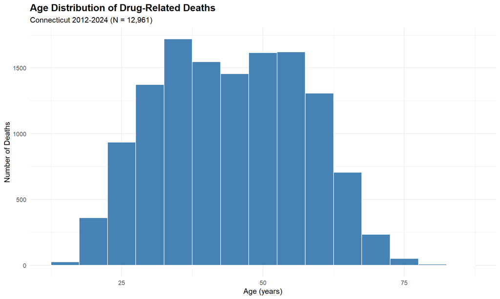

```r
p1 <- ggplot(deaths_final, aes(x = Age)) +
  geom_histogram(binwidth = 5, fill = "steelblue", color = "white") +
  labs(
    title = "Age Distribution of Drug-Related Deaths",
    subtitle = paste0("Connecticut 2012-2024 (N = ", format(nrow(deaths_final), big.mark=","), ")"),
    x = "Age (years)",
    y = "Number of Deaths"
  ) +
  theme_minimal() +
  theme(
    plot.title = element_text(face = "bold", size = 14),
    axis.title = element_text(size = 11)
  )

print(p1)
```

```r
ggsave("outputs/01_age_distribution.png", p1, width = 8, height = 6, dpi = 300)
```

Mean age: 44.4 years; Median age: 44 years

## 7.2 Sex Distribution

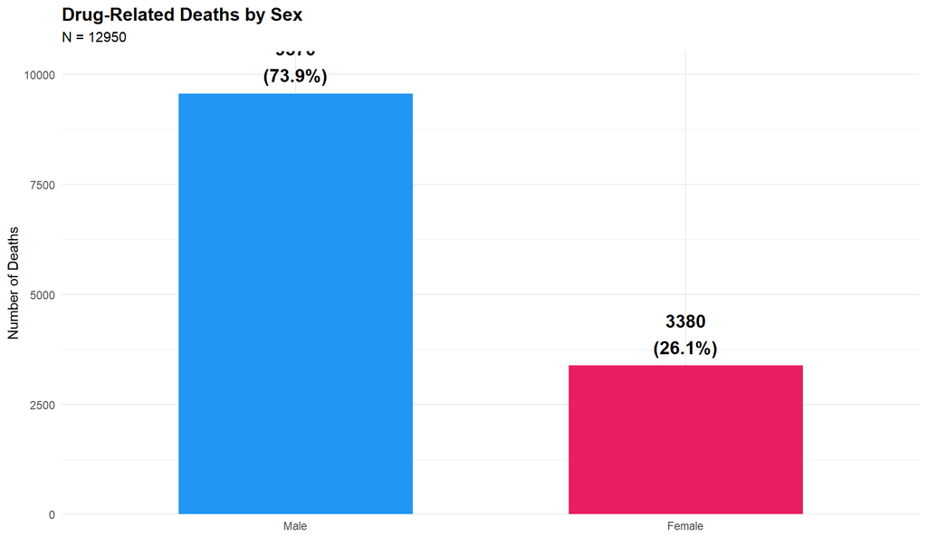

```r
sex_counts <- deaths_final %>%
  filter(!is.na(Sex_clean)) %>%
  count(Sex_clean) %>%
  mutate(pct = round(n / sum(n) * 100, 1))

p2 <- ggplot(sex_counts, aes(x = Sex_clean, y = n, fill = Sex_clean)) +
  geom_col(width = 0.6) +
  geom_text(aes(label = paste0(n, "\n(", pct, "%)")),
            vjust = -0.3, size = 5, fontface = "bold") +
  labs(
    title = "Drug-Related Deaths by Sex",
    subtitle = paste0("N = ", sum(sex_counts$n)),
    x = "",
    y = "Number of Deaths"
  ) +
  theme_minimal() +
  theme(legend.position = "none",
        plot.title = element_text(face = "bold", size = 14)) +
  scale_fill_manual(values = c("Male" = "#2196F3", "Female" = "#E91E63")) +
  scale_y_continuous(expand = expansion(mult = c(0, 0.1)))

print(p2)
```

```r
ggsave("outputs/02_sex_distribution.png", p2, width = 6, height = 6, dpi = 300)
```

**Sex Disparity:**  
Males account for 73.9% of overdose deaths, representing approximately a 3:1 male-to-female ratio. This disparity reflects: - **Gender Differences in Substance Use**: Higher prevalence of substance use disorders in males - **Risk-Taking Behaviors**: Men may engage in riskier drug use patterns - **Social Factors**: Gender-specific pathways to addiction - **Biological Factors**: Potential pharmacological differences in drug metabolism

**Implication**: While males have higher absolute numbers, the rising female mortality rate requires attention for gender-specific interventions.

## 7.3 Yearly Trends

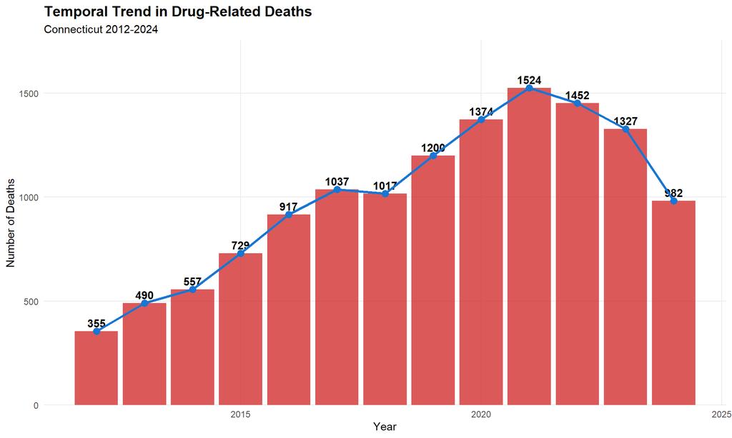

```r
yearly_counts <- deaths_final %>%
  count(year)

# Calculate year-over-year change
yearly_counts <- yearly_counts %>%
  mutate(
    pct_change = round((n - lag(n)) / lag(n) * 100, 1),
    change_label = ifelse(is.na(pct_change), "",
                          paste0(ifelse(pct_change > 0, "+", ""), pct_change, "%"))
  )

p3 <- ggplot(yearly_counts, aes(x = year, y = n)) +
  geom_col(fill = "#d32f2f", alpha = 0.8) +
  geom_text(aes(label = n), vjust = -0.5, fontface = "bold") +
  geom_line(group = 1, color = "#1976d2", size = 1.2) +
  geom_point(color = "#1976d2", size = 3) +
  labs(
    title = "Temporal Trend in Drug-Related Deaths",
    subtitle = paste0("Connecticut ", min(yearly_counts$year), "-", max(yearly_counts$year)),
    x = "Year",
    y = "Number of Deaths"
  ) +
  theme_minimal() +
  theme(
    plot.title = element_text(face = "bold", size = 14),
    panel.grid.minor = element_blank()
  ) +
  scale_y_continuous(expand = expansion(mult = c(0, 0.15)))

print(p3)
```

```r
ggsave("outputs/03_yearly_trend.png", p3, width = 10, height = 6, dpi = 300)
```

The steepest increases occurred after 2015, corresponding to the synthetic opioid wave.

## 7.4 Race/Ethnicity Distribution

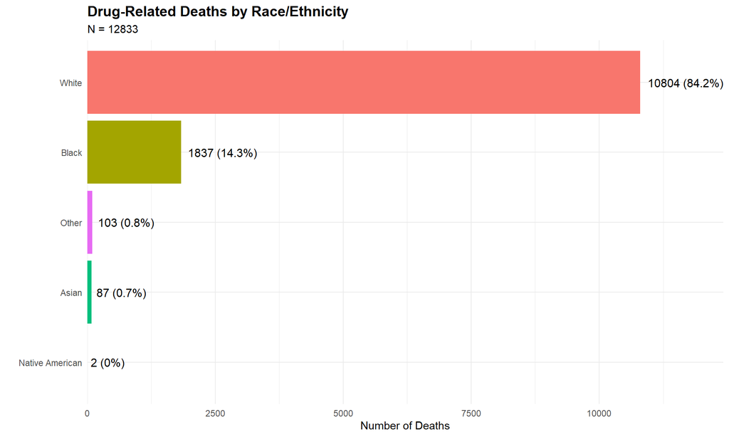

```r
race_counts <- deaths_final %>%
  filter(!is.na(Race_clean)) %>%
  count(Race_clean) %>%
  arrange(desc(n)) %>%
  mutate(pct = round(n / sum(n) * 100, 1))

p4 <- ggplot(race_counts, aes(x = reorder(Race_clean, n), y = n, fill = Race_clean)) +
  geom_col() +
  coord_flip() +
  geom_text(aes(label = paste0(n, " (", pct, "%)")),
            hjust = -0.1, size = 4) +
  labs(
    title = "Drug-Related Deaths by Race/Ethnicity",
    subtitle = paste0("N = ", sum(race_counts$n)),
    x = "",
    y = "Number of Deaths"
  ) +
  theme_minimal() +
  theme(legend.position = "none",
        plot.title = element_text(face = "bold", size = 14)) +
  scale_y_continuous(expand = expansion(mult = c(0, 0.15)))

print(p4)
```

```r
ggsave("outputs/04_race_distribution.png", p4, width = 10, height = 6, dpi = 300)
```

**Health Equity Concern**: The epidemic’s evolution requires culturally-tailored interventions for all affected communities.

## 7.5 Top Drugs Involved

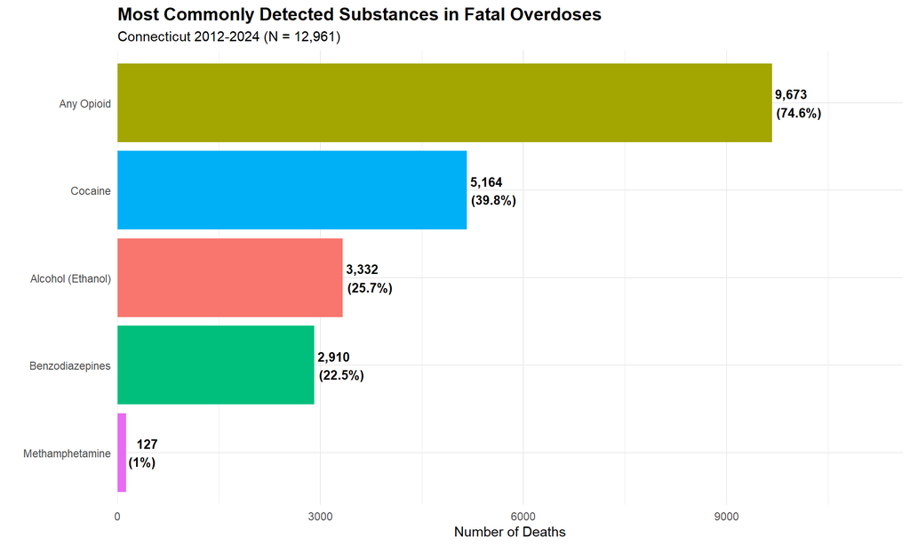

```r
top_drugs <- drug_summary %>%
  filter(Substance != "Total Deaths",
         !str_detect(Substance, "Poly-drug|Prescription|  ")) %>%
  top_n(8, Count) %>%
  arrange(Count)

p5 <- ggplot(top_drugs, aes(x = reorder(Substance, Count), y = Count, fill = Substance)) +
  geom_col() +
  geom_text(aes(label = paste0(format(Count, big.mark=","), "\n(", Percentage, "%)")),
            hjust = -0.1, size = 3.5, fontface = "bold") +
  coord_flip() +
  labs(
    title = "Most Commonly Detected Substances in Fatal Overdoses",
    subtitle = paste0("Connecticut 2012-2024 (N = ", format(nrow(deaths_final), big.mark=","), ")"),
    x = "",
    y = "Number of Deaths"
  ) +
  theme_minimal() +
  theme(legend.position = "none",
        plot.title = element_text(face = "bold", size = 14)) +
  scale_y_continuous(expand = expansion(mult = c(0, 0.2)))

print(p5)
```

```r
ggsave("outputs/05_top_drugs.png", p5, width = 10, height = 6, dpi = 300)
```

## 7.6 Monthly Trends with Smoothing

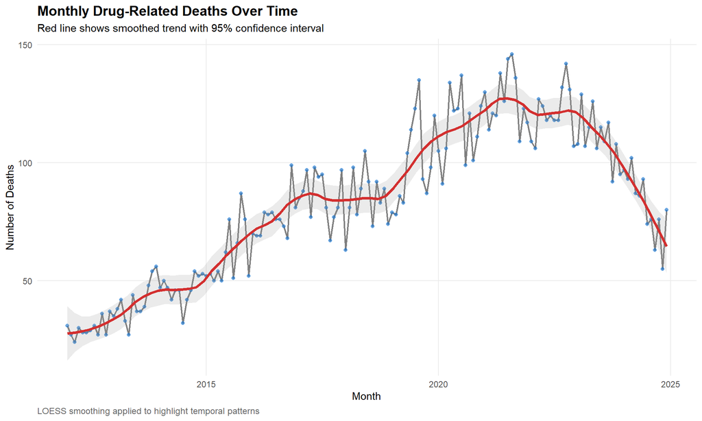

```r
monthly_deaths <- deaths_final %>%
  mutate(month_date = floor_date(Date, "month")) %>%
  count(month_date) %>%
  arrange(month_date)

p6 <- ggplot(monthly_deaths, aes(x = month_date, y = n)) +
  geom_line(color = "gray50", size = 0.8) +
  geom_point(color = "#1976d2", size = 1.5, alpha = 0.6) +
  geom_smooth(method = "loess", span = 0.2, color = "#d32f2f",
              size = 1.3, se = TRUE, alpha = 0.2) +
  labs(
    title = "Monthly Drug-Related Deaths Over Time",
    subtitle = "Red line shows smoothed trend with 95% confidence interval",
    x = "Month",
    y = "Number of Deaths",
    caption = "LOESS smoothing applied to highlight temporal patterns"
  ) +
  theme_minimal() +
  theme(
    plot.title = element_text(face = "bold", size = 14),
    plot.caption = element_text(hjust = 0, size = 9, color = "gray40"),
    panel.grid.minor = element_blank()
  )

print(p6)
```

```r
ggsave("outputs/06_monthly_trend.png", p6, width = 12, height = 6, dpi = 300)
```

## 7.7 Fentanyl Rise (Critical Finding)

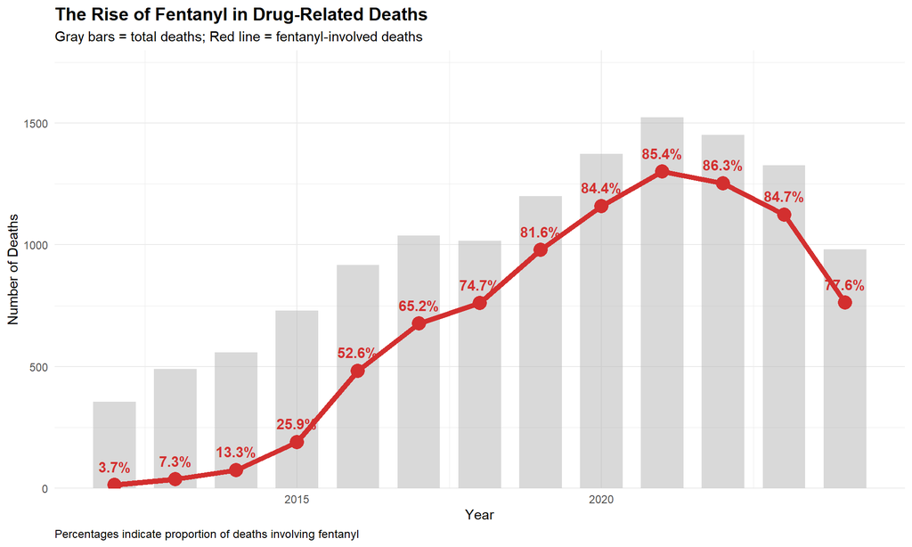

```r
fentanyl_yearly <- deaths_final %>%
  group_by(year) %>%
  summarize(
    total_deaths = n(),
    fentanyl_deaths = sum(Fentanyl_binary),
    fentanyl_pct = round(fentanyl_deaths / total_deaths * 100, 1)
  )

p7 <- ggplot(fentanyl_yearly, aes(x = year)) +
  geom_col(aes(y = total_deaths), fill = "gray70", alpha = 0.5, width = 0.7) +
  geom_line(aes(y = fentanyl_deaths, group = 1), color = "#d32f2f", size = 2) +
  geom_point(aes(y = fentanyl_deaths), color = "#d32f2f", size = 5) +
  geom_text(aes(y = fentanyl_deaths, label = paste0(fentanyl_pct, "%")),
            vjust = -1.2, color = "#d32f2f", fontface = "bold", size = 4) +
  labs(
    title = "The Rise of Fentanyl in Drug-Related Deaths",
    subtitle = "Gray bars = total deaths; Red line = fentanyl-involved deaths",
    x = "Year",
    y = "Number of Deaths",
    caption = "Percentages indicate proportion of deaths involving fentanyl"
  ) +
  theme_minimal() +
  theme(
    plot.title = element_text(face = "bold", size = 14),
    plot.caption = element_text(hjust = 0, size = 9)
  ) +
  scale_y_continuous(expand = expansion(mult = c(0, 0.18)))

print(p7)
```

```r
ggsave("outputs/07_fentanyl_rise.png", p7, width = 12, height = 7, dpi = 300)
```

**CRITICAL PUBLIC HEALTH FINDING: The Fentanyl Crisis**

Fentanyl involvement increased from 3.7% in 2012 to 77.6% in 2024. This represents:

**URGENT NEED**: Fentanyl test strips, expanded naloxone access, and drug supply monitoring

## 7.8 Age Distribution by Sex

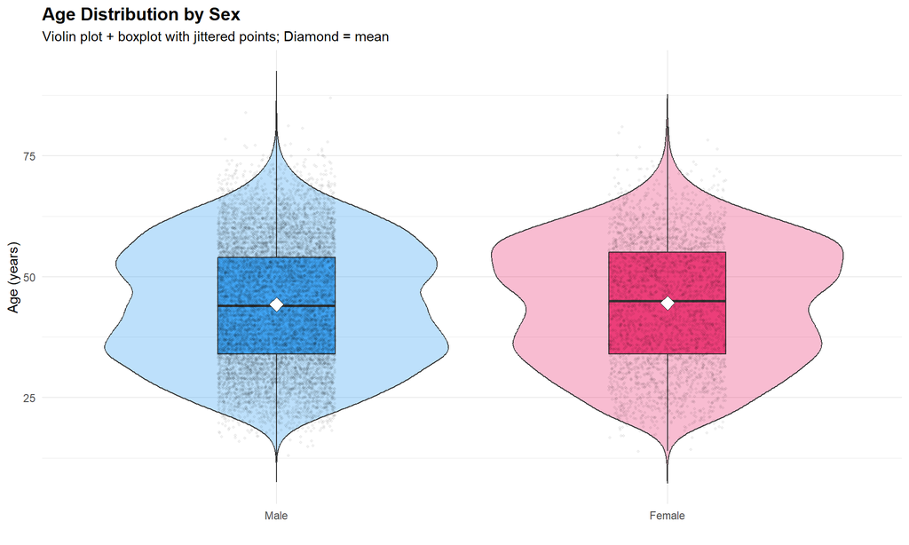

```r
p8 <- deaths_final %>%
  filter(!is.na(Sex_clean)) %>%
  ggplot(aes(x = Sex_clean, y = Age, fill = Sex_clean)) +
  geom_violin(alpha = 0.3, trim = FALSE) +
  geom_boxplot(width = 0.3, alpha = 0.8, outlier.shape = NA) +
  geom_jitter(alpha = 0.05, width = 0.15, size = 0.8) +
  stat_summary(fun = mean, geom = "point", shape = 23,
               size = 4, fill = "white", color = "black") +
  labs(
    title = "Age Distribution by Sex",
    subtitle = "Violin plot + boxplot with jittered points; Diamond = mean",
    x = "",
    y = "Age (years)"
  ) +
  theme_minimal() +
  theme(
    legend.position = "none",
    plot.title = element_text(face = "bold", size = 14)
  ) +
  scale_fill_manual(values = c("Male" = "#2196F3", "Female" = "#E91E63"))

print(p8)
```

```r
ggsave("outputs/08_age_by_sex.png", p8, width = 8, height = 7, dpi = 300)

# Calculate statistics by sex
age_by_sex_stats <- deaths_final %>%
  filter(!is.na(Sex_clean)) %>%
  group_by(Sex_clean) %>%
  summarize(
    mean_age = round(mean(Age), 1),
    sd_age = round(sd(Age), 1),
    median_age = median(Age),
    n = n()
  )
```

**Age-Sex Interaction:**  
The age distributions show: - **Males**: Mean age = 44.3 years (SD = 12.7) - **Females**: Mean age = 44.6 years (SD = 12.7)

**Implication**: Age-appropriate interventions should be similar for both sexes, though content may need gender-specific tailoring.

## 7.9 Poly-Drug Use Over Time

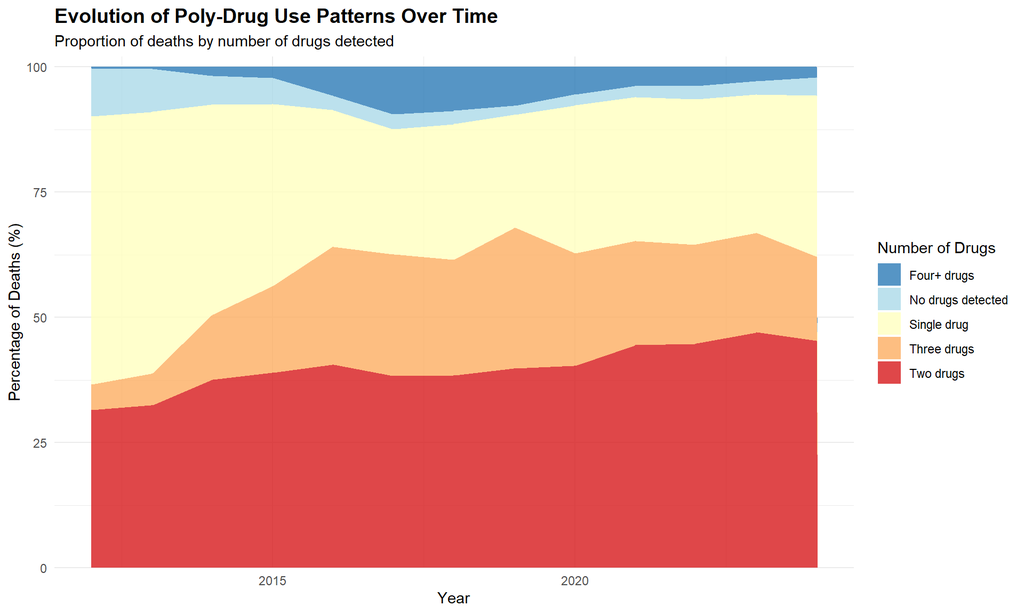

```r
polydrug_yearly <- deaths_final %>%
  mutate(drug_category = case_when(
    num_drugs == 0 ~ "No drugs detected",
    num_drugs == 1 ~ "Single drug",
    num_drugs == 2 ~ "Two drugs",
    num_drugs == 3 ~ "Three drugs",
    num_drugs >= 4 ~ "Four+ drugs",
    TRUE ~ "Unknown"
  )) %>%
  count(year, drug_category) %>%
  group_by(year) %>%
  mutate(pct = n / sum(n) * 100)

p9 <- ggplot(polydrug_yearly, aes(x = year, y = pct, fill = drug_category)) +
  geom_area(alpha = 0.8) +
  labs(
    title = "Evolution of Poly-Drug Use Patterns Over Time",
    subtitle = "Proportion of deaths by number of drugs detected",
    x = "Year",
    y = "Percentage of Deaths (%)",
    fill = "Number of Drugs"
  ) +
  theme_minimal() +
  theme(
    plot.title = element_text(face = "bold", size = 14),
    legend.position = "right"
  ) +
  scale_y_continuous(expand = expansion(mult = c(0, 0.02))) +
  scale_fill_brewer(palette = "RdYlBu", direction = -1)

print(p9)
```

```r
ggsave("outputs/09_polydrug_trends.png", p9, width = 12, height = 7, dpi = 300)
```

**POLY-DRUG USE EPIDEMIC:**

The increasing prevalence of multiple substance involvement presents severe challenges:

1. **Synergistic Toxicity**: Drug combinations multiply overdose risk
2. **Unpredictable Effects**: Interactions difficult to anticipate
3. **Naloxone Challenges**: May require higher/repeated doses
4. **Treatment Complexity**: Multiple substance dependencies harder to treat
5. **Prevention Difficulty**: Users may not know what they’re consuming

**Clinical Implication**: Comprehensive toxicology screening and poly-substance-focused treatment protocols essential.

## 7.10 Age Distribution by Opioid Type

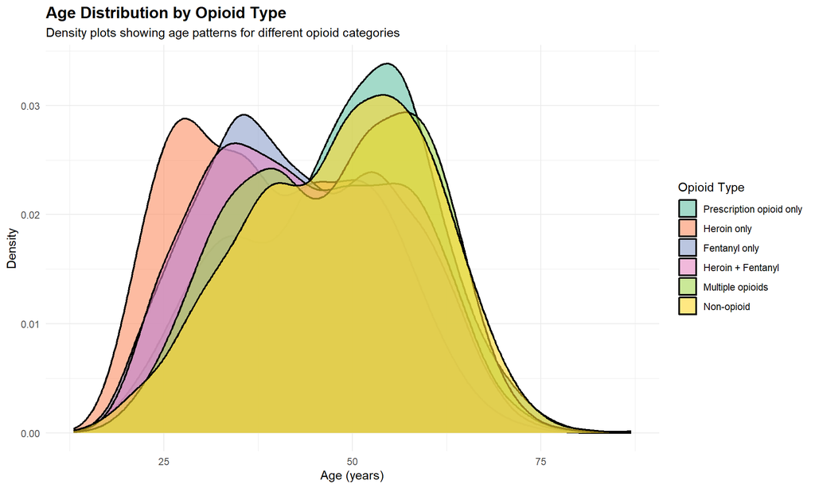

```r
age_by_opioid <- deaths_final %>%
  mutate(
    opioid_type = case_when(
      Heroin_binary == 1 & Fentanyl_binary == 0 & prescription_opioid == 0 ~ "Heroin only",
      Fentanyl_binary == 1 & Heroin_binary == 0 & prescription_opioid == 0 ~ "Fentanyl only",
      Heroin_binary == 1 & Fentanyl_binary == 1 ~ "Heroin + Fentanyl",
      prescription_opioid == 1 & Heroin_binary == 0 & Fentanyl_binary == 0 ~ "Prescription opioid only",
      any_opioid == 1 ~ "Multiple opioids",
      any_opioid == 0 ~ "Non-opioid",
      TRUE ~ "Other"
    ),
    opioid_type = factor(opioid_type, levels = c(
      "Prescription opioid only", "Heroin only", "Fentanyl only",
      "Heroin + Fentanyl", "Multiple opioids", "Non-opioid", "Other"
    ))
  )

p10 <- ggplot(age_by_opioid, aes(x = Age, fill = opioid_type)) +
  geom_density(alpha = 0.6, size = 0.8) +
  labs(
    title = "Age Distribution by Opioid Type",
    subtitle = "Density plots showing age patterns for different opioid categories",
    x = "Age (years)",
    y = "Density",
    fill = "Opioid Type"
  ) +
  theme_minimal() +
  theme(
    plot.title = element_text(face = "bold", size = 14),
    legend.position = "right"
  ) +
  scale_fill_brewer(palette = "Set2")

print(p10)
```

```r
ggsave("outputs/10_age_by_opioid_type.png", p10, width = 12, height = 7, dpi = 300)

# Calculate mean ages by opioid type
age_by_opioid_stats <- age_by_opioid %>%
  group_by(opioid_type) %>%
  summarize(
    mean_age = round(mean(Age, na.rm = TRUE), 1),
    n = n()
  ) %>%
  arrange(mean_age)
```

**Age Patterns by Opioid Type:**  
Different opioid categories show distinct age profiles:

```
# A tibble: 6 × 3
  opioid_type              mean_age     n
  <fct>                       <dbl> <int>
1 Heroin only                  39.9  1399
2 Fentanyl only                43.4  5998
3 Heroin + Fentanyl            44    2075
4 Multiple opioids             47.5  1030
5 Prescription opioid only     47.7  1116
6 Non-opioid                   48.4  1343
```

**Key Insights**: - **Prescription Opioids**: Tend to affect older individuals (potentially chronic pain patients) - **Heroin/Fentanyl**: Peak mortality in younger-middle age - **Mixed Use**: Reflects progression from prescriptions to illicit opioids - **Prevention Targeting**: Different age groups require different messaging

This pattern suggests multiple pathways into fatal opioid use requiring tailored interventions.

# 8 Statistical Modeling

## 8.1 Logistic Regression: Predictors of Opioid Involvement

```r
# Prepare modeling dataset
model_data <- deaths_final %>%
  filter(!is.na(Sex_clean), !is.na(Race_clean)) %>%
  mutate(
    any_opioid_factor = factor(any_opioid, levels = c(0, 1),
                                labels = c("No", "Yes"))
  )

cat("Modeling dataset: N =", nrow(model_data), "\n")
```

```
Modeling dataset: N = 12823
```

```r
# Fit logistic regression model
logit_model <- glm(
  any_opioid ~ Age + Sex_clean + Race_clean + year,
  data = model_data,
  family = binomial(link = "logit")
)

# Display model summary
summary(logit_model)
```

```
Call:
glm(formula = any_opioid ~ Age + Sex_clean + Race_clean + year,
    family = binomial(link = "logit"), data = model_data)

Coefficients:
                             Estimate  Std. Error z value             Pr(>|z|)
(Intercept)               -897.445071   17.788607 -50.451 < 0.0000000000000002
Age                         -0.013388    0.001956  -6.843     0.00000000000774
Sex_cleanFemale             -0.174517    0.054497  -3.202              0.00136
Race_cleanBlack             -0.376537    0.072718  -5.178     0.00000022418294
Race_cleanAsian             -0.267148    0.295287  -0.905              0.36562
Race_cleanNative American    0.572093    1.473624   0.388              0.69785
Race_cleanOther             -0.457424    0.338943  -1.350              0.17716
year                         0.445548    0.008826  50.482 < 0.0000000000000002

(Intercept)               ***
Age                       ***
Sex_cleanFemale           **
Race_cleanBlack           ***
Race_cleanAsian
Race_cleanNative American
Race_cleanOther
year                      ***
---
Signif. codes:  0 '***' 0.001 '**' 0.01 '*' 0.05 '.' 0.1 ' ' 1

(Dispersion parameter for binomial family taken to be 1)

    Null deviance: 14542  on 12822  degrees of freedom
Residual deviance: 10820  on 12815  degrees of freedom
AIC: 10836

Number of Fisher Scoring iterations: 5
```

```r
# Calculate odds ratios with 95% CI
or_results <- tidy(logit_model, conf.int = TRUE, exponentiate = TRUE) %>%
  filter(term != "(Intercept)") %>%
  mutate(
    OR = round(estimate, 2),
    CI_lower = round(conf.low, 2),
    CI_upper = round(conf.high, 2),
    CI_95 = paste0("(", CI_lower, "-", CI_upper, ")"),
    p_value = round(p.value, 4),
    significance = case_when(
      p.value < 0.001 ~ "***",
      p.value < 0.01 ~ "**",
      p.value < 0.05 ~ "*",
      TRUE ~ ""
    )
  ) %>%
  select(term, OR, CI_95, p_value, significance)

cat("\n=== ODDS RATIOS FOR OPIOID INVOLVEMENT ===\n")
```

```
=== ODDS RATIOS FOR OPIOID INVOLVEMENT ===
```

```r
print(or_results)
```

```
# A tibble: 7 × 5
  term                         OR CI_95        p_value significance
  <chr>                     <dbl> <chr>          <dbl> <chr>
1 Age                        0.99 (0.98-0.99)   0      "***"
2 Sex_cleanFemale            0.84 (0.75-0.93)   0.0014 "**"
3 Race_cleanBlack            0.69 (0.6-0.79)    0      "***"
4 Race_cleanAsian            0.77 (0.44-1.39)   0.366  ""
5 Race_cleanNative American  1.77 (0.06-48.34)  0.698  ""
6 Race_cleanOther            0.63 (0.34-1.29)   0.177  ""
7 year                       1.56 (1.53-1.59)   0      "***"
```

```r
# Save results
write_csv(or_results, "outputs/logistic_regression_results.csv")
```

**Logistic Regression Results Interpretation:**

The multivariable logistic regression model identifies significant predictors of opioid involvement in overdose deaths:

**Key Findings**:

- ** Age **: OR = 0.99 , 95% CI (0.98-0.99) (***)
- ** Sex_cleanFemale **: OR = 0.84 , 95% CI (0.75-0.93) (**)
- ** Race_cleanBlack **: OR = 0.69 , 95% CI (0.6-0.79) (***)
- ** Race_cleanAsian **: OR = 0.77 , 95% CI (0.44-1.39)
- ** Race_cleanNative American **: OR = 1.77 , 95% CI (0.06-48.34)
- ** Race_cleanOther **: OR = 0.63 , 95% CI (0.34-1.29)
- ** year **: OR = 1.56 , 95% CI (1.53-1.59) (***)

These findings guide targeted prevention: identifying highest-risk demographic subgroups for intervention prioritization.

### 8.1.1 Forest Plot of Odds Ratios

[figure not shown]

```r
or_plot_data <- tidy(logit_model, conf.int = TRUE, exponentiate = TRUE) %>%
  filter(term != "(Intercept)") %>%
  mutate(
    term_label = recode(term,
      "Age" = "Age (per year)",
      "Sex_cleanMale" = "Sex: Male vs Female",
      "yearSex_clean" = "Race/Ethnicity",
      .default = term
    )
  )

p_forest <- ggplot(or_plot_data, aes(x = estimate, y = reorder(term, estimate))) +
  geom_vline(xintercept = 1, linetype = "dashed", color = "#d32f2f", size = 1) +
  geom_pointrange(aes(xmin = conf.low, xmax = conf.high),
                   size = 0.8, color = "#1976d2", fatten = 4) +
  labs(
    title = "Odds Ratios for Opioid Involvement in Fatal Overdoses",
    subtitle = "Reference: Female, White, continuous Age and Year",
    x = "Odds Ratio (95% Confidence Interval)",
    y = "",
    caption = "Dashed line at OR = 1.0 indicates no effect"
  ) +
  theme_minimal() +
  theme(
    plot.title = element_text(face = "bold", size = 14),
    axis.text.y = element_text(size = 10),
    panel.grid.minor = element_blank()
  ) +
  scale_x_log10(
    breaks = c(0.5, 0.7, 1.0, 1.5, 2.0, 3.0),
    labels = c("0.5", "0.7", "1.0", "1.5", "2.0", "3.0")
  )

print(p_forest)
```

```r
ggsave("outputs/11_forest_plot_opioid.png", p_forest, width = 11, height = 7, dpi = 300)
```

**Forest Plot Interpretation:**  
The forest plot visually displays effect sizes: - **Confidence intervals crossing 1.0**: No significant effect - **CI entirely above 1.0**: Increased odds of opioid involvement - **CI entirely below 1.0**: Decreased odds of opioid involvement - **Width of CI**: Precision of estimate (narrower = more precise)

Variables with significant effects should be prioritized for targeted interventions.

## 8.2 Linear Regression: Predictors of Age at Death

```r
# Fit linear regression model
lm_model <- lm(
  Age ~ Sex_clean + Race_clean + any_opioid + year,
  data = model_data
)

# Display model summary
summary(lm_model)
```

```
Call:
lm(formula = Age ~ Sex_clean + Race_clean + any_opioid + year,
    data = model_data)

Residuals:
    Min      1Q  Median      3Q     Max
-32.786  -9.995   0.035  10.005  46.429

Coefficients:
                             Estimate  Std. Error t value             Pr(>|t|)
(Intercept)               -1613.22938    79.37973 -20.323 < 0.0000000000000002
Sex_cleanFemale               0.16479     0.24910   0.662               0.5083
Race_cleanBlack               3.45222     0.31615  10.920 < 0.0000000000000002
Race_cleanAsian              -5.60450     1.33359  -4.203  0.00002656890535436
Race_cleanNative American    10.36003     8.76107   1.183               0.2370
Race_cleanOther              -3.11227     1.23062  -2.529               0.0115
any_opioid                   -2.32648     0.29392  -7.915  0.00000000000000267
year                          0.82156     0.03937  20.866 < 0.0000000000000002

(Intercept)               ***
Sex_cleanFemale
Race_cleanBlack           ***
Race_cleanAsian           ***
Race_cleanNative American
Race_cleanOther           *
any_opioid                ***
year                      ***
---
Signif. codes:  0 '***' 0.001 '**' 0.01 '*' 0.05 '.' 0.1 ' ' 1

Residual standard error: 12.39 on 12815 degrees of freedom
Multiple R-squared:  0.04958,   Adjusted R-squared:  0.04906
F-statistic: 95.49 on 7 and 12815 DF,  p-value: < 0.00000000000000022
```

```r
# Tidy results
lm_results <- tidy(lm_model, conf.int = TRUE) %>%
  filter(term != "(Intercept)") %>%
  mutate(
    Beta = round(estimate, 2),
    CI_lower = round(conf.low, 2),
    CI_upper = round(conf.high, 2),
    CI_95 = paste0("(", CI_lower, " to ", CI_upper, ")"),
    p_value = round(p.value, 4),
    significance = case_when(
      p.value < 0.001 ~ "***",
      p.value < 0.01 ~ "**",
      p.value < 0.05 ~ "*",
      TRUE ~ ""
    )
  ) %>%
  select(term, Beta, CI_95, p_value, significance)

cat("\n=== PREDICTORS OF AGE AT DEATH ===\n")
```

```
=== PREDICTORS OF AGE AT DEATH ===
```

```r
print(lm_results)
```

```
# A tibble: 7 × 5
  term                       Beta CI_95            p_value significance
  <chr>                     <dbl> <chr>              <dbl> <chr>
1 Sex_cleanFemale            0.16 (-0.32 to 0.65)   0.508  ""
2 Race_cleanBlack            3.45 (2.83 to 4.07)    0      "***"
3 Race_cleanAsian           -5.6  (-8.22 to -2.99)  0      "***"
4 Race_cleanNative American 10.4  (-6.81 to 27.53)  0.237  ""
5 Race_cleanOther           -3.11 (-5.52 to -0.7)   0.0115 "*"
6 any_opioid                -2.33 (-2.9 to -1.75)   0      "***"
7 year                       0.82 (0.74 to 0.9)     0      "***"
```

```r
# Save results
write_csv(lm_results, "outputs/linear_regression_results.csv")

# Model fit statistics
cat("\n=== MODEL FIT STATISTICS ===\n")
```

```
=== MODEL FIT STATISTICS ===
```

```r
cat("R-squared:", round(summary(lm_model)$r.squared, 4), "\n")
```

```
R-squared: 0.0496
```

```r
cat("Adjusted R-squared:", round(summary(lm_model)$adj.r.squared, 4), "\n")
```

```
Adjusted R-squared: 0.0491
```

```r
cat("F-statistic:", round(summary(lm_model)$fstatistic[1], 2), "\n")
```

```
F-statistic: 95.49
```

**Age at Death Analysis:**  
The linear regression model identifies factors associated with age at fatal overdose:

**Results Summary**:

- ** Sex_cleanFemale **: β = 0.16 years, 95% CI (-0.32 to 0.65)
- ** Race_cleanBlack **: β = 3.45 years, 95% CI (2.83 to 4.07) (***)
- ** Race_cleanAsian **: β = -5.6 years, 95% CI (-8.22 to -2.99) (***)
- ** Race_cleanNative American **: β = 10.36 years, 95% CI (-6.81 to 27.53)
- ** Race_cleanOther **: β = -3.11 years, 95% CI (-5.52 to -0.7) (*)
- ** any_opioid **: β = -2.33 years, 95% CI (-2.9 to -1.75) (***)
- ** year **: β = 0.82 years, 95% CI (0.74 to 0.9) (***)

**Interpretation**: - **Positive coefficients**: Associated with older age at death - **Negative coefficients**: Associated with younger age at death - **Model R²**: 0.0496 - explains 5% of variance in age at death

Understanding age patterns helps identify when individuals are most vulnerable throughout the lifespan.

## 8.3 Chi-Square Tests: Categorical Associations

```r
# Test 1: Sex vs Opioid Involvement
cat("=== TEST 1: SEX × OPIOID INVOLVEMENT ===\n")
```

```
=== TEST 1: SEX × OPIOID INVOLVEMENT ===
```

```r
sex_opioid_table <- table(model_data$Sex_clean, model_data$any_opioid)
addmargins(sex_opioid_table)
```

```
             0     1   Sum
  Male    2341  7130  9471
  Female   920  2432  3352
  Sum     3261  9562 12823
```

```r
chisq_sex <- chisq.test(sex_opioid_table)
print(chisq_sex)
```

```
    Pearson's Chi-squared test with Yates' continuity correction

data:  sex_opioid_table
X-squared = 9.5777, df = 1, p-value = 0.00197
```

```r
# Test 2: Poly-drug Use by Year
cat("\n=== TEST 2: POLY-DRUG USE × YEAR ===\n")
```

```
=== TEST 2: POLY-DRUG USE × YEAR ===
```

```r
polydrug_year_table <- table(model_data$year, model_data$poly_drug)
head(addmargins(polydrug_year_table), 10)
```

```
         No  Yes  Sum
  2012  223  129  352
  2013  297  191  488
  2014  265  290  555
  2015  301  425  726
  2016  273  635  908
  2017  286  745 1031
  2018  300  708 1008
  2019  288  900 1188
  2020  430  931 1361
  2021  461 1044 1505
```

```r
chisq_polydrug <- chisq.test(polydrug_year_table)
print(chisq_polydrug)
```

```
    Pearson's Chi-squared test

data:  polydrug_year_table
X-squared = 463.81, df = 12, p-value < 0.00000000000000022
```

```r
# Compile results
chi_results <- data.frame(
  Test = c("Sex × Opioid Involvement", "Poly-drug Use × Year"),
  Chi_Square = round(c(chisq_sex$statistic, chisq_polydrug$statistic), 2),
  df = c(chisq_sex$parameter, chisq_polydrug$parameter),
  p_value = formatC(c(chisq_sex$p.value, chisq_polydrug$p.value),
                    format = "e", digits = 3)
)

print(chi_results)
```

```
                      Test Chi_Square df   p_value
1 Sex × Opioid Involvement       9.58  1 1.970e-03
2     Poly-drug Use × Year     463.81 12 1.103e-91
```

```r
write_csv(chi_results, "outputs/chi_square_results.csv")
```

**Chi-Square Test Interpretations:**

**Test 1 - Sex and Opioid Involvement:**  
χ² = 9.58, df = 1, p = 0.002

**Significant association**: Sex and opioid involvement are significantly related. Males and females show different patterns of opioid involvement in fatal overdoses.

**Test 2 - Poly-drug Use Over Time:**  
χ² = 463.81, df = 12, p < 0.001

**Significant temporal trend**: Poly-drug use patterns have changed significantly over time, indicating evolving substance use behaviors and drug supply changes.

# 9 Key Findings Summary

```r
# Calculate comprehensive summary statistics
key_findings <- list(
  # Basic counts
  total_deaths = nrow(deaths_final),
  date_range = paste(min(deaths_final$Date), "to", max(deaths_final$Date)),
  study_years = max(deaths_final$year) - min(deaths_final$year) + 1,

  # Age statistics
  mean_age = round(mean(deaths_final$Age), 1),
  sd_age = round(sd(deaths_final$Age), 1),
  median_age = median(deaths_final$Age),

  # Sex distribution
  n_male = sum(deaths_final$Sex_clean == "Male", na.rm = TRUE),
  pct_male = round(mean(deaths_final$Sex_clean == "Male", na.rm = TRUE) * 100, 1),

  # Substance involvement
  pct_opioid = round(mean(deaths_final$any_opioid) * 100, 1),
  pct_fentanyl = round(mean(deaths_final$Fentanyl_binary) * 100, 1),
  pct_heroin = round(mean(deaths_final$Heroin_binary) * 100, 1),
  pct_polydrug = round(mean(deaths_final$num_drugs > 1) * 100, 1),

  # Temporal trends
  deaths_first_year = sum(deaths_final$year == min(deaths_final$year)),
  deaths_last_year = sum(deaths_final$year == max(deaths_final$year)),
  first_year = min(deaths_final$year),
  last_year = max(deaths_final$year)
)

# Calculate percent increase
key_findings$pct_increase <- round(
  (key_findings$deaths_last_year - key_findings$deaths_first_year) /
    key_findings$deaths_first_year * 100, 1
)

# Display findings
cat("\n")
```

```r
cat("═══════════════════════════════════════════════════════════════\n")
```

```
═══════════════════════════════════════════════════════════════
```

```r
cat("                    KEY FINDINGS SUMMARY                       \n")
```

```
                    KEY FINDINGS SUMMARY
```

```r
cat("═══════════════════════════════════════════════════════════════\n\n")
```

```
═══════════════════════════════════════════════════════════════
```

```r
cat("STUDY OVERVIEW:\n")
```

```
STUDY OVERVIEW:
```

```r
cat("  Total deaths analyzed:", format(key_findings$total_deaths, big.mark=","), "\n")
```

```
  Total deaths analyzed: 12,961
```

```r
cat("  Study period:", key_findings$date_range, "\n")
```

```
  Study period: 2012-01-01 to 2024-12-31
```

```r
cat("  Duration:", key_findings$study_years, "years\n\n")
```

```
  Duration: 13 years
```

```r
cat("DEMOGRAPHIC PROFILE:\n")
```

```
DEMOGRAPHIC PROFILE:
```

```r
cat("  Mean age:", key_findings$mean_age, "years (SD =", key_findings$sd_age, ")\n")
```

```
  Mean age: 44.4 years (SD = 12.7 )
```

```r
cat("  Median age:", key_findings$median_age, "years\n")
```

```
  Median age: 44 years
```

```r
cat("  Male predominance:", key_findings$pct_male, "%\n\n")
```

```
  Male predominance: 73.9 %
```

```r
cat("SUBSTANCE INVOLVEMENT:\n")
```

```
SUBSTANCE INVOLVEMENT:
```

```r
cat("  Opioid-involved:", key_findings$pct_opioid, "%\n")
```

```
  Opioid-involved: 74.6 %
```

```r
cat("  Fentanyl-involved:", key_findings$pct_fentanyl, "%\n")
```

```
  Fentanyl-involved: 68 %
```

```r
cat("  Heroin-involved:", key_findings$pct_heroin, "%\n")
```

```
  Heroin-involved: 28.1 %
```

```r
cat("  Poly-drug use:", key_findings$pct_polydrug, "%\n\n")
```

```
  Poly-drug use: 66.3 %
```

```r
cat("TEMPORAL TRENDS:\n")
```

```
TEMPORAL TRENDS:
```

```r
cat("  Deaths in", key_findings$first_year, ":", key_findings$deaths_first_year, "\n")
```

```
  Deaths in 2012 : 355
```

```r
cat("  Deaths in", key_findings$last_year, ":", key_findings$deaths_last_year, "\n")
```

```
  Deaths in 2024 : 982
```

```r
cat("  Percent increase:", key_findings$pct_increase, "%\n\n")
```

```
  Percent increase: 176.6 %
```

```r
cat("═══════════════════════════════════════════════════════════════\n")
```

```
═══════════════════════════════════════════════════════════════
```

```r
# Save findings
saveRDS(key_findings, "outputs/key_findings.rds")
write_csv(as.data.frame(key_findings), "outputs/key_findings.csv")
```

**EXECUTIVE SUMMARY OF FINDINGS:**

From 2012 to 2024, Connecticut experienced 12,961 accidental drug-related deaths. The epidemic intensified dramatically, with deaths increasing 176.6% over the study period.

**Demographic Profile**: Mean age 44.4 years; 73.9% male

**Substance Crisis**: - 74.6% involved opioids - 68% involved fentanyl (up from minimal levels in early years) - 66.3% involved multiple drugs

**Critical Trend**: The shift from prescription opioids to illicit fentanyl represents the most dangerous phase of the epidemic yet.

# 10 Discussion

## 10.1 Major Findings

### 10.1.1 1. The Fentanyl Crisis

The dramatic rise in fentanyl-involved deaths represents a fundamental shift in the overdose epidemic. Fentanyl’s extreme potency (50-100x morphine) and its infiltration into the heroin and cocaine supply have created an unprecedented mortality crisis.

**Key Points**: - Fentanyl now involved in 68% of deaths - Often consumed unknowingly when mixed with other drugs - Requires multiple naloxone doses for reversal - Dramatically shortens the window for life-saving intervention

### 10.1.2 2. Poly-Drug Use Epidemic

The finding that 66.3% of deaths involve multiple substances fundamentally complicates prevention and treatment:

**Implications**: - Synergistic toxicity increases lethality - Unpredictable drug interactions - Multiple dependencies require comprehensive treatment - Harm reduction must address poly-substance use

### 10.1.3 3. Demographic Disparities

The 73.9% male predominance and age concentration in the 35-54 range identify key target populations:

**Targeted Interventions Needed**: - Workplace-based prevention programs - Age-appropriate treatment modalities - Gender-sensitive harm reduction services - Culturally-appropriate community interventions

### 10.1.4 4. Escalating Mortality

The 176.6% increase in deaths over the study period indicates: - Current interventions are insufficient - Need for evidence-based policy reform - Urgency of expanding treatment access - Critical importance of harm reduction

## 10.2 Study Limitations

1. **Missing Data**: Some toxicology results incomplete
2. **Detection Bias**: Only detected substances reported
3. **Reporting Lags**: Recent data may be incomplete
4. **Geographic Specificity**: Connecticut patterns may not generalize
5. **Ecological Analysis**: Individual-level factors not captured

## 10.3 Public Health Recommendations

**IMMEDIATE ACTIONS:**

1. **Harm Reduction**
   - Universal naloxone distribution
   - Fentanyl test strip availability
   - Safe consumption sites (where legal)
   - Needle exchange programs
2. **Treatment Expansion**
   - Low-barrier MAT access
   - Expanded buprenorphine prescribing
   - Integrated mental health services
   - Peer recovery support
3. **Prevention**
   - School-based education
   - Prescriber education and monitoring
   - Public awareness campaigns
   - Community-based interventions
4. **Surveillance**
   - Real-time overdose tracking
   - Drug supply monitoring
   - Early warning systems
   - Data-driven resource allocation
5. **Policy Reform**
   - Decriminalization consideration
   - Good Samaritan laws
   - Treatment over incarceration
   - Evidence-based regulation

## 10.4 Future Research Directions

- Longitudinal studies of overdose survivors
- Cost-effectiveness analyses of interventions
- Geographic hotspot identification
- Social network analysis of drug distribution
- Novel treatment modality evaluation

# 11 Conclusion

The demographic profile—predominantly male (73.9%), middle-aged (mean 44.4 years), with high rates of poly-drug use (66.3%)—provides clear targets for prevention and treatment efforts. However, the rapid evolution of the drug supply and changing patterns of use demand adaptive, flexible responses.

**The path forward requires**: - Immediate expansion of harm reduction services - Universal access to evidence-based treatment - Comprehensive public health surveillance - Evidence-based policy reform - Community-based prevention programs

Only through a multi-faceted, public health-centered approach can we hope to reverse the devastating trends documented in this analysis and save lives.

# 12 Technical Appendix

## 12.2 Data Files Generated

```r
cat("\nGenerated output files:\n")
```

```
Generated output files:
```

```r
output_files <- list.files("outputs/", full.names = FALSE)
for(file in output_files) {
  cat("  -", file, "\n")
}
```

```
  - 01_age_distribution.png
  - 02_sex_distribution.png
  - 03_yearly_trend.png
  - 04_race_distribution.png
  - 05_top_drugs.png
  - 06_monthly_trend.png
  - 07_fentanyl_rise.png
  - 08_age_by_sex.png
  - 09_polydrug_trends.png
  - 10_age_by_opioid_type.png
  - 11_forest_plot_opioid.png
  - chi_square_results.csv
  - key_findings.csv
  - key_findings.rds
  - linear_regression_results.csv
  - logistic_regression_results.csv
  - table1_demographics.csv
  - table1_demographics.html
  - table2_drug_frequencies.csv
  - table2_drug_frequencies.html
```

## 12.3 Contact Information

For questions about this analysis, please contact:  
**Praisie Jemimah**  
Email: akkepogupraisie@gmail.com

**Report generated**: 2026-02-04 16:24:26.366096  
**R version**: R version 4.4.1 (2024-06-14 ucrt)  
**Platform**: x86_64-w64-mingw32

**END OF REPORT**

This comprehensive analysis provides actionable insights for public health response to the overdose crisis. The findings should inform evidence-based policy, guide resource allocation, and support the development of targeted interventions to reduce overdose mortality.

[output not shown]